# Assignment01

Suchan Park

2017 10 5

# 4.1.1 ex02

## (a)

```r
n<-c(1:30)
fn <- function(i)
{
  if (i==1 || i==2)
  {
    return (1)
  }
  return (fn(i-1)+fn(i-2))
}

fnValue<-{} #Store Fibonacci values
for(i in n)
{
  fnValue<-c(fnValue, fn(i))
}
for (i in c(2:length(fnValue)))
{
  print (fnValue[i]/fnValue[i-1])
}
```

```
## [1] 1
## [1] 2
## [1] 1.5
## [1] 1.666667
## [1] 1.6
## [1] 1.625
## [1] 1.615385
## [1] 1.619048
## [1] 1.617647
## [1] 1.618182
## [1] 1.617978
## [1] 1.618056
## [1] 1.618026
## [1] 1.618037
## [1] 1.618033
## [1] 1.618034
## [1] 1.618034
## [1] 1.618034
## [1] 1.618034
## [1] 1.618034
## [1] 1.618034
## [1] 1.618034
## [1] 1.618034
## [1] 1.618034
## [1] 1.618034
## [1] 1.618034
## [1] 1.618034
## [1] 1.618034
## [1] 1.618034
```

The sequence is converging to 1.618034.

## (b)

```r
k<-(1+sqrt(5))/2
k
```

```
## [1] 1.618034
```

Yes. I can prove this with Golden Rectangle.

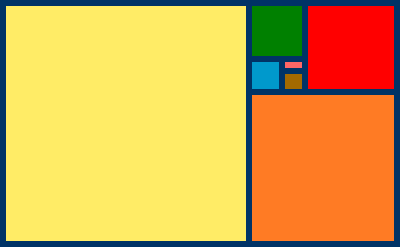

Assume that x1 is the half of pink area above pricture. x1 is a square with width 1. Then, the pink partition is a rectangle of width 2 and height 1. I set the pink is x1 +x2. Then the brown partition is a square with width 2. I will call this x3. Then, the blue partition is a square with with 1+2. I will call this x4. Like this, the partition in the picture can be considered as a component of Fibonacci sequence. Golden ratio is a ratio of successive side lengths in Golden square. Therefore, the sequence of (a) is converging to the ratid.

# 4.1.1 ex03

## (a)

```r
answer<-0
for(j in 1:5)
  answer <- answer + j
paste("The answer is ", answer)
```

```
## [1] "The answer is  15"
```

## (b)

```r
answer<-NULL
for(j in 1:5)
  answer <- c(answer, j)
answer
```

```
## [1] 1 2 3 4 5
```

## (c)

```r
answer<-0
for(j in 1:5)
  answer<-c(answer,j)
answer
```

```
## [1] 0 1 2 3 4 5
```

## (d)

```r
answer<-1
for(j in 1:5)
  answer<-answer * j
paste("The answer is ", answer)
```

```
## [1] "The answer is  120"
```

## (e)

```r
answer<-3
for(j in 1:15)
  answer<-c(answer, (7* answer[j])%%31)

answer
```

```
##  [1]  3 21 23  6 11 15 12 22 30 24 13 29 17 26 27  3
```

The sequence will be repeated from 16th.

# 4.1.2 ex04

```r
GIC <- function(P, n)
{
  if (n<=3)
  {
    i=0.04
    return (P*((1+i)^n-1))
  }else
  {
    i=0.05
    return (P*((1+i)^n-1))
  }
}
```

# 4.1.2 ex05

```r
Mortage<-function(n,P,open)
{
  if (open==TRUE)
  {
    i=0.005
    return (P*i/(1-(1+i)^(-n)))
  }else
  {
    i=0.004
    return (P*i/(1-(1+i)^(-n)))
  }
}
```

# 4.1.3 ex02

```r
Fib1<-1
Fib2<-1
Fibonacci<-c(Fib1,Fib2)
while(Fib2<300)  ##Original Fibonacci
{
  Fibonacci<-c(Fibonacci,Fib2)
  oldFib2<-Fib2
  Fib2<-Fib1 + Fib2
  Fib1<-oldFib2
}
print("Original Fibonacci Function")
```

```
## [1] "Original Fibonacci Function"
```

```r
Fibonacci[-1] ## The value at the first is not required
```

```
##  [1]   1   1   2   3   5   8  13  21  34  55  89 144 233
```

```r
#Modified Fibonacci
Fibonacci<-c(1,1)
while (Fibonacci[length(Fibonacci)]<300)  #Modified Fibonacci
{
  Fibonacci<-c(Fibonacci,Fibonacci[length(Fibonacci)])
  Fibonacci[1]<-Fibonacci[length(Fibonacci)]
  Fibonacci[length(Fibonacci)]<-Fibonacci[length(Fibonacci)-1]+Fibonacci[length(Fibonacci)-2]
  Fibonacci[length(Fibonacci)-1]<-Fibonacci[1]
  Fibonacci[1]<-1
}
print("Modified Fibonacci Function")
```

```
## [1] "Modified Fibonacci Function"
```

```r
Fibonacci[-length(Fibonacci)] #The value at the last is not required
```

```
##  [1]   1   1   2   3   5   8  13  21  34  55  89 144 233
```

# 4.1.3 ex04 & 05

```r
#Original Problem
i<-0.006
for(j in 1:1000)
{
  i<-(1-(1+i)^(-20))/19
}
i
```

```
## [1] 0.004935593
```

```r
#ex04 & ex05 - While loop & the number of iteration
i<-0.006
j<-0
num<-0
while(abs(i-j)>0.000001)
{
  j<-i
  i<-(1-(1+i)^(-20))/19
  #print(abs(i-j)) Show the difference of two seccessive i's
  num<-num+1
}
i
```

```
## [1] 0.004954139
```

```r
paste("The number of iterations is ",num)
```

```
## [1] "The number of iterations is  74"
```

# 4.1.5 ex02

## (a)

```r
E1 <- function(n){
  if(n>=2)
  {
    sieve <-seq(2,n)
    primes<-c()
    num<-0
    while(length(sieve)>0)
    {
      p<-sieve[1]
      primes<-c(primes,p)
      sieve<-sieve[(sieve %% p) != 0] #Element which is not divided by p can be stored in sieve again.
      num<-num+1
    }
    return(primes)
  }else {
    stop("Input value of n should be at least 2.")
  }
}
E1(20)  #Check the function works well
```

```
## [1]  2  3  5  7 11 13 17 19
```

## (b)

```
Explain 01
Assume that
 If N is a composite number, n does not have a divisor which is smaller than sqrt(n)
 N = a*b.
 So 2<= a<=b<n
 a>sqrt(n) and b>sqrt(n)
 so a*b >n
 It menas N=a*b >N =>Contradiction
 Therefore, If N has is a composite number, n will have a prime divisor which is smaller or equal than sqrt(n)
 So, if n does not have a prime divisor, N must be a prime number.

Explain 02
 N=a*b.
 At least one of them must be smaller or equal to root N.
 So, if we try to divide N in to 2 to sqrt(N), N must be divided if the N is composite number.
```

## (c) Modify the function

```r
E2 <- function(n){
  if(n>=2)
  {
    sieve <-seq(2,n)
    primes<-c()
    num<-0
    while(length(sieve)>0)
    {
      p<-sieve[1]
      if(p>=sqrt(n))
      {
        primes<-c(primes,sieve)
        break
      }
      primes<-c(primes,p)
      sieve<-sieve[(sieve %% p) != 0]
      num<-num+1
    }
    #print(num)
    return(primes)
  }else {
    stop("Input value of n should be at least 2.")
  }
}
E2(20) #Check the function also works well
```

```
## [1]  2  3  5  7 11 13 17 19
```

# 4.2.1 ex02

## (a)

```r
compound.interest<-function(P,i,n)
{
  return (P*(1+i)^n)
}
```

## (b)

```r
compound.interest(1000,0.01,30)
```

```
## [1] 1347.849
```

# 4.2.1 ex03

```r
func<-function(x) { 3*x-1}
bisection<-function(f,a,b)
{
  if (f(a)*f(b)>0)
  {
    print("f(a) and f(b) must have opposite signs")
    break
  }else
  {
    c<-(a+b)/2
    while(abs(f(c))>0.00001)
    {
      if(f(a)*f(c)<0)
      {
        b<-c
      }else
      {
        a<-c
      }
      c<-(a+b)/2
    }
    paste("The value of root is ",c)
  }
}
bisection(func,-2,2)
```

```
## [1] "The value of root is  0.333335876464844"
```

# 4.4.1 ex01

```r
mergesort<-function(x, la) #la = logical argument, TRUE => Decreasing
{
  len<-length(x)
  if(len<2)
  {
    result<-x
  }else
  {
    y<-x[1:(len/2)]
    z<-x[(len/2+1):len]
    y<-mergesort(y,la)
    z<-mergesort(z,la)

    result<-c()
    if(la==TRUE)
    {
      while(min(length(y), length(z))>0)
      {
        if(y[1]<z[1])
        {
          result<-c(result,z[1])
          z<-z[-1]

        }else
        {
          result<-c(result,y[1])
          y<-y[-1]
        }
      }
    }else
    {
      while(min(length(y), length(z))>0)
      {
        if(y[1]<z[1])
        {
          result<-c(result, y[1])
          y<-y[-1]
        }else
        {
          result<-c(result,z[1])
          z<-z[-1]
        }
      }
    }
    if(length(y)>0)
      result<-c(result,y)
    else
      result<-c(result,z)
  }
  return(result)
}
test<-c(6,5,7,2,2,3,6,10)
test
```

```
## [1]  6  5  7  2  2  3  6 10
```

```r
mergesort(test,TRUE) #Print decreasing
```

```
## [1] 10  7  6  6  5  3  2  2
```

```r
mergesort(test,FALSE) #Print increasing
```

```
## [1]  2  2  3  5  6  6  7 10
```

# 4.4.1 ex02

## (a)

```r
#install.packages("Deriv")  #I used Deriv packages to find differentiate of a function.
library(Deriv)
Newton<-function(f,g,a,b)
{
  fx<-function(f,x,y)
  {
    f_<-eval(Deriv(f,"x")) #f_ is the derivative function by x
    f1<-f_(x,y)
    return(f1)
  }
  fy<-function(f,x,y) #f_ is the derivative function by y
  {
    f_<-eval(Deriv(f,"y"))
    f2<-f_(x,y)
    return(f2)
  }
  gx<-function(g,x,y)
  {
    g_<-eval(Deriv(g,"x")) #g_ is the derivative function by x
    g1<-g_(x,y)
    return(g1)
  }
  gy<-function(g,x,y)
  {
    g_<-eval(Deriv(g,"y")) #g_ is the derivative function by y
    g2<-g_(x,y)
    return(g2)
  }

  x<-a
  y<-b
  f1<-f(x,y)
  g1<-g(x,y)

  while(abs(f1)>0.00001 || abs(g1)>0.00001) #while loop will stop where both of the two value are closed to zero
  {
    d<-(fx(f,x,y)*gy(g,x,y)-fy(f,x,y)*gx(g,x,y))

    x1<-x-(gx(g,x,y)*f(x,y)-fy(f,x,y)*g(x,y))/d
    y1<-y-(fx(f,x,y)*g(x,y)-gy(g,x,y)*f(x,y))/d
    #print(c(f(x1,y1),g(x1,y1),d))
    f1<-f(x1,y1)
    g1<-g(x1,y1)
    x<-x1
    y<-y1
  }
  paste("X : ", x, ", Y : ", y, ", f(x,y) : ", f(x,y), ", g(x,y) : ", g(x,y))

}
f<-function(x,y)
{
  x+y
}
g<-function(x,y)
{
  x^2+2*y^2-2
}
Newton(f,g,-2,2)  #Test
```

```
## [1] "X :  -0.816498123868988 , Y :  0.816498123868988 , f(x,y) :  0 , g(x,y) :  7.55884473324642e-06"
```

## (b)

If we compute the system manually, we can find two solutions. (x,y) = (-0.816…, 0.816…) or (0.816…, -0.816…)

The computed solution of (a) is the same with the first solution of (b)

If we set initial value (2,-2), then we can get (x,y) = (0.816…, -0.816…)

The variety of solution is from the initial position.

# Chapter4 ex01

```r
directpoly<-function(x, coeff)
{
  n<-length(coeff)
  value<-0
  for( i in 1:n)
  {
    value<-value+coeff[i]*x^(n-i)
  }
  return (value)
}
coef<-c(1,2,3,4,5) # 1*x^4 + 2*x^3 + 3*x^2 +4*x + 5
directpoly(2,coef)
```

```
## [1] 57
```

# Chapter4 ex02

```r
hornerpoly<-function(x,coeff)
{
  n<-length(coeff)
  value<-coeff[1]
  for(i in 2:n)
  {
    value<-value*x+coeff[i]
  }
  return (value)
}
coef<-c(1,2,3,4,5) # 1*x^4 + 2*x^3 + 3*x^2 +4*x + 5
directpoly(2,coef)
```

```
## [1] 57
```

# Chapter4 ex03

## (a)

```r
system.time(directpoly(x=seq(-10,10, length=5000000), c(1,-2,2,3,4,6,7)))
```

```
##    user  system elapsed
##   1.103   0.076   1.181
```

```r
# elapsed time : total consuming time for the code
# user time + system time = elapsed time
# user time : only for the program
# system time : time for OS
system.time(hornerpoly(x=seq(-10,10,length=5000000),c(1,-2,2,3,4,6,7)))
```

```
##    user  system elapsed
##   0.152   0.032   0.184
```

We can find that hornerpoly is much faster than directpoly

## (b)

```r
system.time(directpoly(x=seq(-10,10, length=5000000), c(2,17,-3)))
```

```
##    user  system elapsed
##   0.196   0.020   0.216
```

```r
system.time(hornerpoly(x=seq(-10,10,length=5000000),c(2,17,-3)))
```

```
##    user  system elapsed
##   0.089   0.013   0.102
```

As the number of polynomial coefficients is smaller, the time difference of two methods becomes also smaller.